# Ch 5 exercises

## C

Binning et al (2013) studied the effect of ectoparasitic isopods (*Anilocra nemipteri*) on the swimming ability of a tropical species of bream (*Scolopsis bilineatus*). They collected 18 unparasitized and 20 parasitized fish from Lizard Island on the Great Barrier Reef and created four treatment groups in the laboratory: eight unparasitized fish, 10 parasitized fish, 10 parasitized fish that had the parasites removed, and ten unparasitized fish that had model parasites made of plastic added. They recorded the swimming speed (body lengths per second) and oxygen consumption (mgO<sub>2</sub> per kg per hour) of each fish, in a respirometer. The data are available from [datadryad](https://datadryad.org/stash/dataset/doi:10.5061/dryad.r73v3). Within dryad, the dataset you want is “binning etal 2012 one way anova.txt”; in this dataset, SMR is Standard Metabolic Rate (O<sub>2</sub> consumption), AS = factorial aerobic scope, and Ucrit is swimming speed.

In Chapter 4’s exercises, you should have described a model to fit to these data.

**What are the assumptions associated with that model?**

> Variances similar among groups

> Independence

**Read in the data and check the assumptions**

```r
df <- read.csv("data/binning.csv")
head(df,10)
```

|  | Fish | Treatment | SMR | MMR | AS | Ucrit |
| --- | --- | --- | --- | --- | --- | --- |
| 1 | P10 | P | 110 | 536 | 4.86 | 3.79 |
| 2 | P12 | P | 140 | 471 | 3.36 | 3.66 |
| 3 | P27 | P | 136 | 573 | 4.22 | 2.47 |
| 4 | P42 | P | 140 | 380 | 2.70 | 3.65 |
| 5 | P15 | P | 121 | 562 | 4.66 | 3.52 |
| 6 | P23 | P | 108 | 376 | 3.48 | 3.39 |
| 7 | P26 | P | 119 | 535 | 4.49 | 3.74 |
| 8 | P37 | P | 153 | 495 | 3.24 | 3.37 |
| 9 | P72 | P | 101 | 430 | 4.26 | 3.36 |
| 10 | P75 | P | 134 | 435 | 3.24 | 3.68 |

Look at boxplots to start

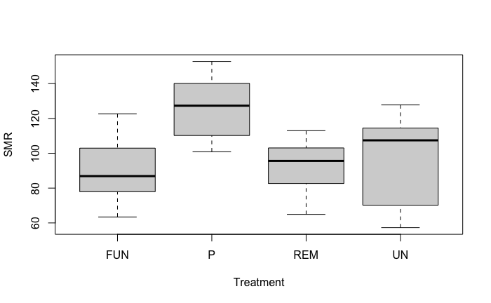

```r
boxplot(SMR ~ Treatment, data=df)
```

Then fit linear model and check residuals

```r
binning.lm <- lm(SMR ~ Treatment, data= df)
augment(binning.lm)
```

| SMR | Treatment | .fitted | .resid | .hat | .sigma | .cooksd | .std.resid |
| --- | --- | --- | --- | --- | --- | --- | --- |
| 110.2 | P | 126.2 | -16.006 | 0.100 | 19.7 | 2.06e-02 | -0.8611 |
| 140.1 | P | 126.2 | 13.904 | 0.100 | 19.7 | 1.55e-02 | 0.7480 |
| 135.8 | P | 126.2 | 9.634 | 0.100 | 19.8 | 7.46e-03 | 0.5183 |
| 140.4 | P | 126.2 | 14.234 | 0.100 | 19.7 | 1.63e-02 | 0.7658 |
| 120.5 | P | 126.2 | -5.666 | 0.100 | 19.9 | 2.58e-03 | -0.3048 |
| 108.0 | P | 126.2 | -18.186 | 0.100 | 19.6 | 2.66e-02 | -0.9784 |
| 119.2 | P | 126.2 | -6.976 | 0.100 | 19.8 | 3.91e-03 | -0.3753 |
| 152.7 | P | 126.2 | 26.524 | 0.100 | 19.3 | 5.66e-02 | 1.4270 |
| 100.9 | P | 126.2 | -25.346 | 0.100 | 19.3 | 5.17e-02 | -1.3636 |
| 134.1 | P | 126.2 | 7.884 | 0.100 | 19.8 | 5.00e-03 | 0.4242 |

[output cut: 28 more lines]

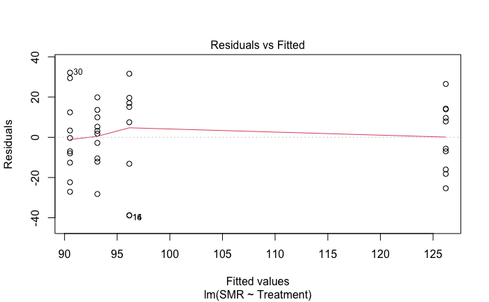

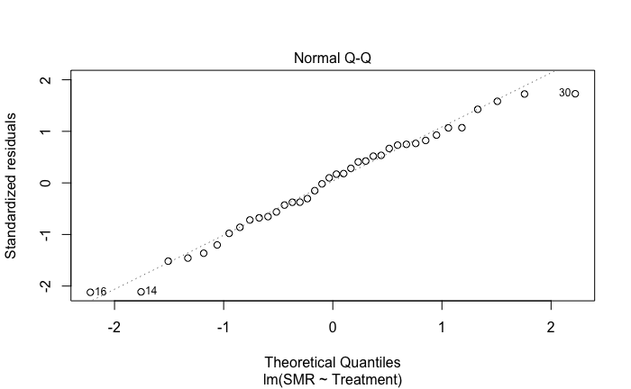

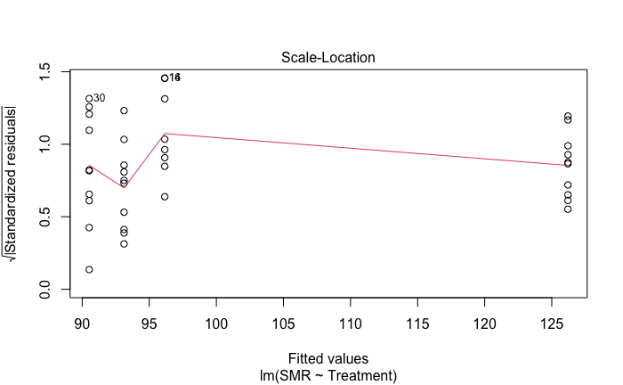

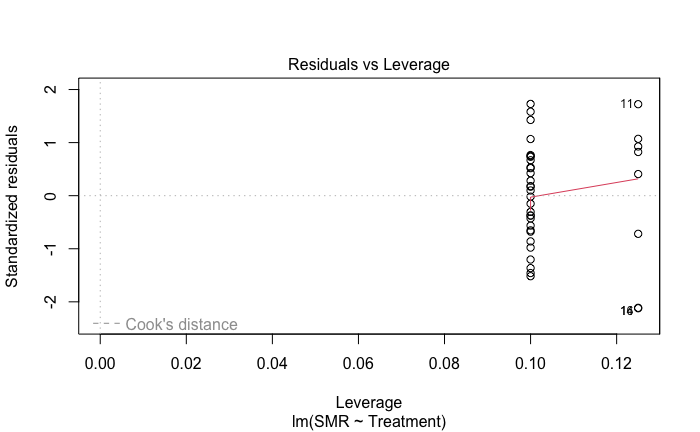

```r
plot(binning.lm)
```

Repeat for Ucrit and AS

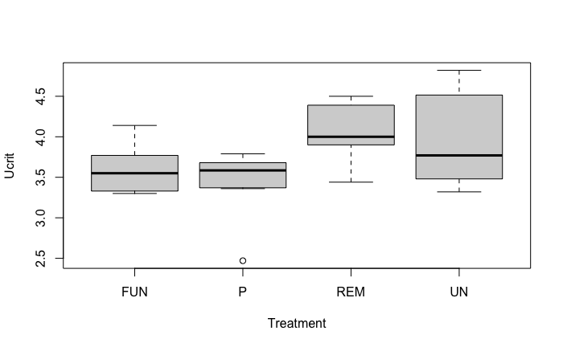

```r
boxplot(Ucrit ~ Treatment, data=df)
```

```r
binning.lm <- lm(Ucrit ~ Treatment, data= df)
augment(binning.lm)
```

| Ucrit | Treatment | .fitted | .resid | .hat | .sigma | .cooksd | .std.resid |
| --- | --- | --- | --- | --- | --- | --- | --- |
| 3.79 | P | 3.46 | 0.32700 | 0.100 | 0.417 | 1.92e-02 | 0.83076 |
| 3.66 | P | 3.46 | 0.19700 | 0.100 | 0.420 | 6.96e-03 | 0.50049 |
| 2.47 | P | 3.46 | -0.99300 | 0.100 | 0.380 | 1.77e-01 | -2.52277 |
| 3.65 | P | 3.46 | 0.18700 | 0.100 | 0.420 | 6.27e-03 | 0.47508 |
| 3.52 | P | 3.46 | 0.05700 | 0.100 | 0.421 | 5.83e-04 | 0.14481 |
| 3.39 | P | 3.46 | -0.07300 | 0.100 | 0.421 | 9.55e-04 | -0.18546 |
| 3.74 | P | 3.46 | 0.27700 | 0.100 | 0.418 | 1.38e-02 | 0.70373 |
| 3.37 | P | 3.46 | -0.09300 | 0.100 | 0.421 | 1.55e-03 | -0.23627 |
| 3.36 | P | 3.46 | -0.10300 | 0.100 | 0.421 | 1.90e-03 | -0.26168 |
| 3.68 | P | 3.46 | 0.21700 | 0.100 | 0.419 | 8.44e-03 | 0.55130 |

[output cut: 28 more lines]

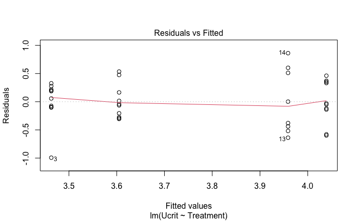

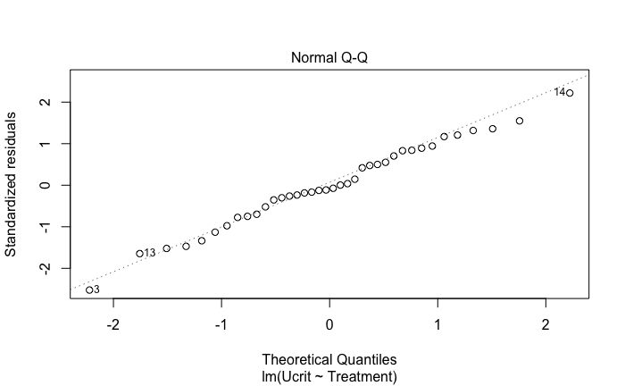

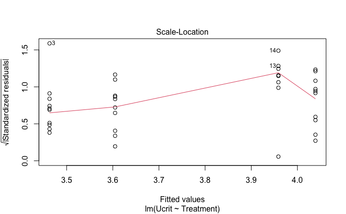

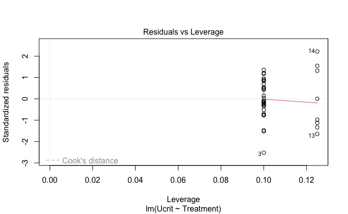

```r
plot(binning.lm)
```

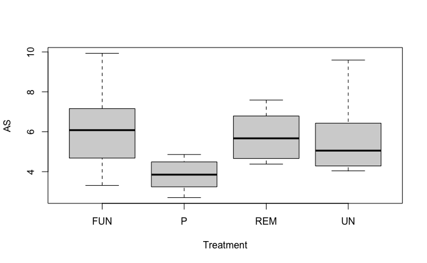

```r
boxplot(AS ~ Treatment, data=df)
```

```r
binning.lm <- lm(AS ~ Treatment, data= df)
augment(binning.lm)
```

| AS | Treatment | .fitted | .resid | .hat | .sigma | .cooksd | .std.resid |
| --- | --- | --- | --- | --- | --- | --- | --- |
| 4.86 | P | 3.85 | 1.009 | 0.100 | 1.50 | 1.41e-02 | 0.7125 |
| 3.36 | P | 3.85 | -0.491 | 0.100 | 1.51 | 3.34e-03 | -0.3467 |
| 4.22 | P | 3.85 | 0.369 | 0.100 | 1.51 | 1.89e-03 | 0.2606 |
| 2.70 | P | 3.85 | -1.151 | 0.100 | 1.50 | 1.83e-02 | -0.8127 |
| 4.66 | P | 3.85 | 0.809 | 0.100 | 1.51 | 9.06e-03 | 0.5712 |
| 3.48 | P | 3.85 | -0.371 | 0.100 | 1.51 | 1.91e-03 | -0.2620 |
| 4.49 | P | 3.85 | 0.639 | 0.100 | 1.51 | 5.66e-03 | 0.4512 |
| 3.24 | P | 3.85 | -0.611 | 0.100 | 1.51 | 5.17e-03 | -0.4314 |
| 4.26 | P | 3.85 | 0.409 | 0.100 | 1.51 | 2.32e-03 | 0.2888 |
| 3.24 | P | 3.85 | -0.611 | 0.100 | 1.51 | 5.17e-03 | -0.4314 |

[output cut: 28 more lines]

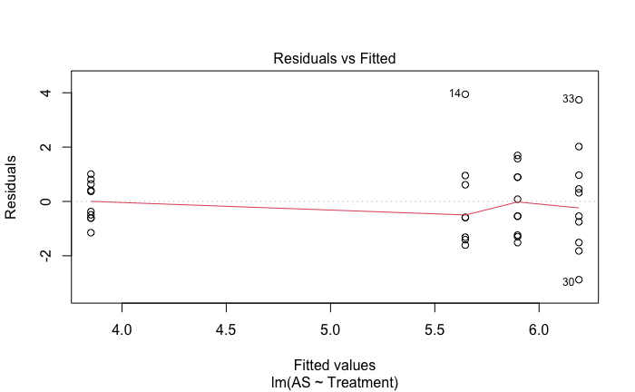

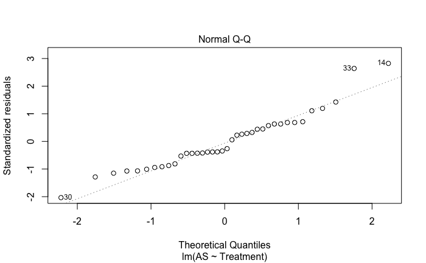

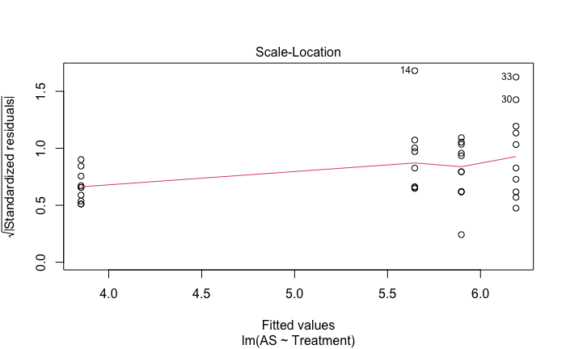

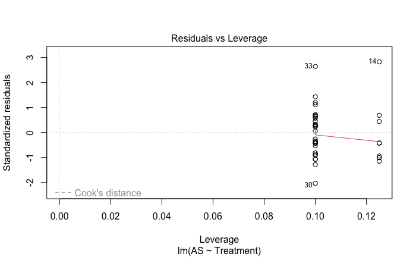

```r
plot(binning.lm)
```

> For AS, some hint of variance heterogeneity, but not large. No issues for Ucrit

## D

[Kaufman et al. (2013)](https://doi.org/10.1371/journal.pone.0058667) examined the neuroanatomy of a recently described species of sengi, which are small insectivorous mammals also known as elephant or jumping shrews. These animals are interesting, having been originally placed with the mammalian order Insectivora, along with shrews, hedgehogs, moles, etc., but this group is now known to be polyphyletic, and sengis are more appropriately grouped with elephants, dugongs, and hyraxes. They are in the order Macroscelidea, within the Afrotheria. The Afrotheria includes another order of small insectivores, the Tenrecoidea (tenrecs and golden moles). The Laurasiatheria also includes several families of small insectivores

Small insectivores are generally thought to have small brain mass (when adjusted for overall mass), but there has been some question of whether sengis fit this pattern, and Kaufman and colleagues were curious whether the new species, *Rhynchocyon udzungwensis*, fitted with other sengi. They assembled data from 56 small insectivores, 5 sengi, 14 afrotherian species, and 37 laurasiatherians. For each species, they calculated brain mass (in mg) and total body mass (g).

Data are all presented in Table 1 of the paper. We’ve extracted it from the paper and it’s here kaufman.csv

In the exercises for this chapter, we’ll just think about brain size relative to body size, and we’ll pick this example up again in Chapter 8.

Load the data file, and look at the relationship between brain mass and body mass.

```r
df <- read.csv("data/kaufman.csv")
head(df,10)
```

|  | family | genus | species | bodymass | brainmass | relation | relation2 |
| --- | --- | --- | --- | --- | --- | --- | --- |
| 1 | Solenodontidae | Solenodon | paradoxus | 672.0 | 4723 | laurasiatherian | other insectivore |
| 2 | Tenrecidae | Tenrec | ecaudatus | 852.0 | 2588 | afrotherian | other insectivore |
| 3 | Tenrecidae | Setifer | setosus | 237.0 | 1516 | afrotherian | other insectivore |
| 4 | Tenrecidae | Hemicentetes | semispin | 116.0 | 839 | afrotherian | other insectivore |
| 5 | Tenrecidae | Echinops | telfairi | 87.5 | 623 | afrotherian | other insectivore |
| 6 | Tenrecidae | Oryzorictes | talpoides | 44.2 | 580 | afrotherian | other insectivore |
| 7 | Tenrecidae | Microgale | cowani | 15.2 | 420 | afrotherian | other insectivore |
| 8 | Tenrecidae | Limnogale | mergulus | 92.0 | 1150 | afrotherian | other insectivore |
| 9 | Tenrecidae | Microgale | dobsoni | 31.9 | 557 | afrotherian | other insectivore |
| 10 | Tenrecidae | Microgale | talazaci | 48.2 | 766 | afrotherian | other insectivore |

** What kind of model are we intending to fit to these data?**

Look at the relationship between the two variables? Are there any steps you’d recommend we take?

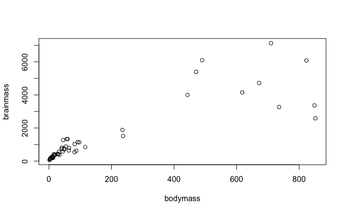

```r
plot(brainmass~bodymass, data=df)
```

> Relationship not very linear; not even worth looking at residuals. Try log-transformation.

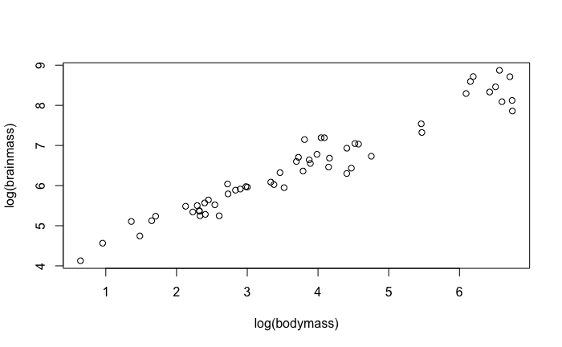

```r
plot(log(brainmass)~log(bodymass), data=df)
```

> Looks much better. Fit linear model so we can get residuals

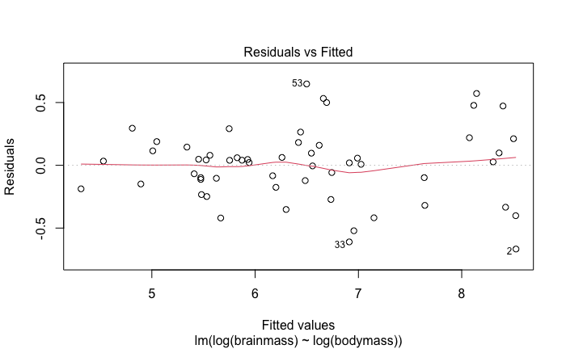

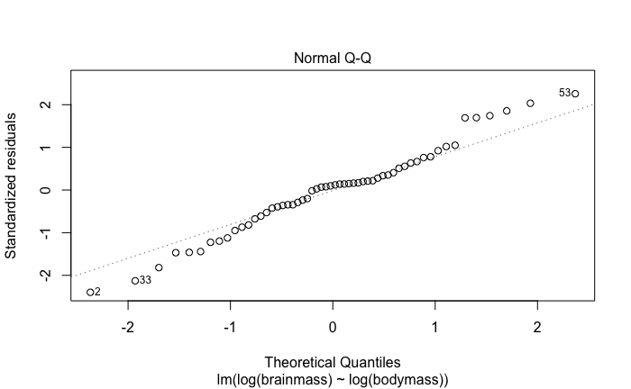

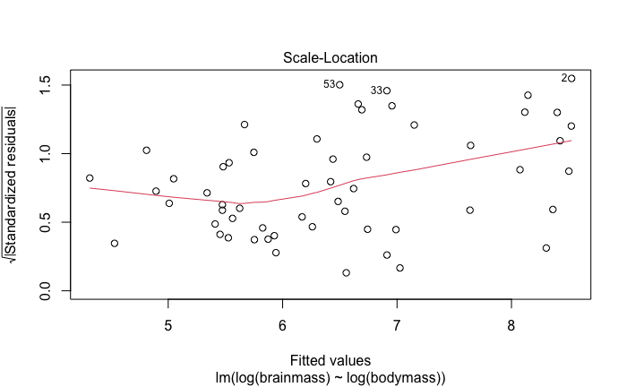

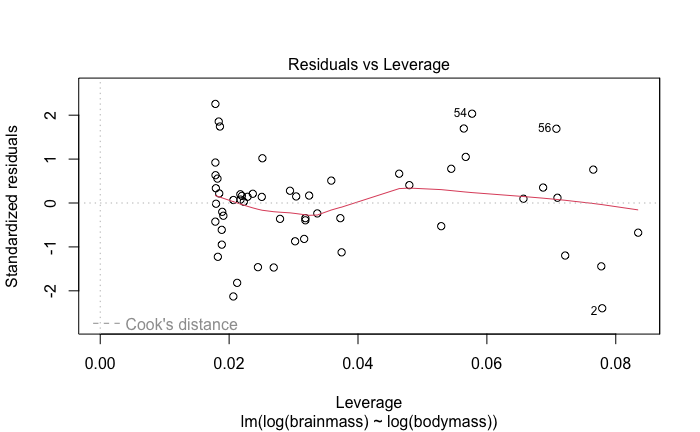

```r
lm1<-lm(log(brainmass)~log(bodymass), data=df)
plot(lm1)
```

```r
augment(lm1)
```

| log(brainmass) | log(bodymass) | .fitted | .resid | .hat | .sigma | .cooksd | .std.resid |
| --- | --- | --- | --- | --- | --- | --- | --- |
| 8.46 | 6.510 | 8.36 | 0.09831 | 0.0687 | 0.292 | 4.56e-03 | 0.3516 |
| 7.86 | 6.748 | 8.53 | -0.66693 | 0.0779 | 0.276 | 2.43e-01 | -2.3971 |
| 7.32 | 5.468 | 7.64 | -0.31928 | 0.0375 | 0.289 | 2.45e-02 | -1.1232 |
| 6.73 | 4.754 | 7.15 | -0.41815 | 0.0245 | 0.287 | 2.68e-02 | -1.4612 |
| 6.43 | 4.472 | 6.96 | -0.52136 | 0.0212 | 0.283 | 3.59e-02 | -1.8188 |
| 6.36 | 3.789 | 6.48 | -0.12189 | 0.0179 | 0.292 | 1.64e-03 | -0.4245 |
| 6.04 | 2.721 | 5.75 | 0.29152 | 0.0252 | 0.290 | 1.34e-02 | 1.0190 |
| 7.05 | 4.522 | 6.99 | 0.05702 | 0.0217 | 0.292 | 4.40e-04 | 0.1990 |
| 6.32 | 3.463 | 6.26 | 0.06256 | 0.0185 | 0.292 | 4.47e-04 | 0.2180 |
| 6.64 | 3.875 | 6.54 | 0.09652 | 0.0179 | 0.292 | 1.03e-03 | 0.3361 |

[output cut: 46 more lines]

> The residual plot flags data points 2, 54 and 56. Not a concern, as 54 and 56 are species of interest (Sengi). Record 2 is a species of tenrec. As a researcher, you might check this point, as it will have high leverage. In the scatterplot, it doesn’t seem wildly off the line.

> Let’s play with some fancier graphics, using ggplot

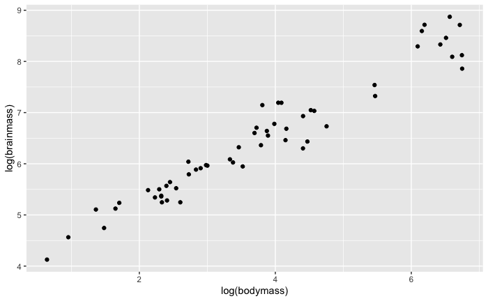

```r
ggplot(data=df, aes(x=log(bodymass), y=log(brainmass)))+
  geom_point()
```

> Now add a smoother

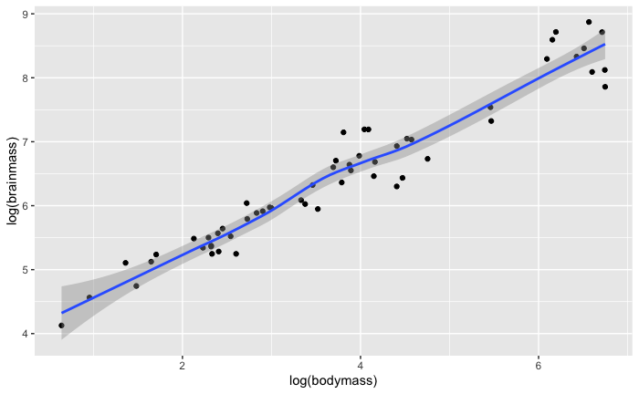

```r
ggplot(data=df, aes(x=log(bodymass), y=log(brainmass)))+
  geom_point()+
  geom_smooth()
```

*Note that the original researchers used a reduced major axis regression, as they considered both variables measured with error. Note the discussion in Chapter 6 about whether to consider X random or fixed. For our purposes, we’ll treat it as fixed*

> The research questions are about differences among sengi and between sengi and other insectivores. There are 3 groups of insectivores, sengis and closely (afrotherian) and more distantly (laurasiatherian) species, and the research question is about where sengis fit. Use different colours/symbols for the 3 groups

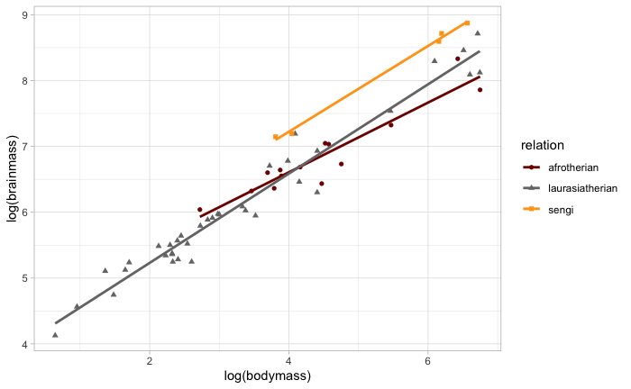

```r
ggplot(data=df, aes(x=log(bodymass), y=log(brainmass), group = relation, colour = relation, shape = relation))+
  geom_point() + geom_smooth(method = "lm", se = FALSE) + theme_light() + scale_color_uchicago()
```

### References

Binning, S. A., D. G. Roche, and C. Layton. 2013. Ectoparasites increase swimming costs in a coral reef fish. *Biology Letters* **9**:20120927. doi:10.1098/rsbl.2012.0927

Kaufman JA, Turner GH, Holroyd PA, Rovero F, Grossman A (2013) Brain Volume of the Newly-Discovered Species *Rhynchocyon udzungwensis* (Mammalia: Afrotheria: Macroscelidea): Implications for Encephalization in Sengis*. PLoS ONE 8(3): e58667.* doi:10.1371/journal.pone.0058667

Le Boeuf, B. J., Crocker, D. E., Costa, D. P., Blackwell, S. B., Webb, P. M. & Houser, D. S. (2000). Foraging ecology of northern elephant seals. *Ecological Monographs*, 70, 353-82.

Peake, A. J. & Quinn, G. P. (1993). Temporal variation in species-area curves for invertebrates in clumps of an intertidal mussel. *Ecography*, 16, 269-77.

Vosteen, I., Gershenzon, J. & Kunert, G. (2016). Hoverfly preference for high honeydew amounts creates enemy-free space for aphids colonizing novel host plants. *J Anim Ecol*, 85, 1286-97.